# Mapping Emergency Demand: The Deprivation, Demographic, Disease Burden and Department Patterns Behind Frequent A&E Attendance in Scotland

Public Health Scotland Project

Fenanda Dwitha Kurniasari (S2744048)

2026-08-13

# 1 Packages

```r
library(tidyverse) # for data manipulation and tidying
library(MASS) # loaded for glm.nb() compatibility checks only. glmmTMB is used for all reported models
library(broom)
library(broom.mixed)
library(glmmTMB) # for main model
library(dplyr) # for data manipulation and tidying
library(performance) # icc(), check_collinearity()
library(DHARMa) # model checking
library(scales)
library(janitor)
library(readxl) # import excel
library(corrplot)
library(sf) # for import shp file
library(patchwork)
library(conflicted)


# to fix conflicting function select(), filter(), rename() between MASS and dplyr
conflicted::conflicts_prefer(dplyr::select, dplyr::filter, dplyr::rename, .quiet = TRUE)

# setting default size output
theme_set(theme_minimal(base_size = 12))
eda_theme <- theme_minimal(base_size = 12) +
  theme(
    plot.title = element_text(face = "bold", size = 14),
    plot.subtitle = element_text(size = 10, colour = "grey40", margin = margin(b = 8)),
    panel.grid.minor = element_blank(),
    panel.border = element_rect(colour = "grey30", fill = NA, linewidth = 0.6),
    axis.title = element_text(size = 10.5)
  )

# every figure below is saved at dpi = 300; only width/height vary,
# so wrap the repeated ggsave() call in one helper
save_fig <- function(filename, plot = last_plot(), width, height, dpi = 300) {
  ggsave(file.path("Figures", filename), plot = plot, width = width, height = height, dpi = dpi)
}
```

# 2 Data and Exploration

## 2.1 Data Sources (2.1)

Three sources feed this analysis: PHS Multiple Attendances Demographics (the outcome, one row per stratum), PHS General Practice disease prevalence at Health Board level, and NRS mid-year 2025 population estimates used as the model offset.

```r
#PHS Multiple Attendances Demographics (rolling 12 months to April 2026)
#one row per stratum (hbt x age x sex x deprivation x department_type)
multiple_attendance <- read.csv("Data/multiple attendance_demographic.csv",
                                na.strings = c("", "NA")) %>% clean_names()

#PHS General Practice disease prevalence, Health Board level, 2025
disease_prevalence_raw <- read_excel("Data/diseaseprevalenceingeneralpractice_board_total.xlsx",
                                     sheet = "DP_Board_total") %>% clean_names()

# spatial data
hb_boundaries <- st_read("Data/SG_NHS_HealthBoards_2019/SG_NHS_HealthBoards_2019.shp")
# Area name -> Health Board code (hbt)
hb_name_to_code <- tibble::tribble(
  ~gp_practice_area, ~hbt,
  "NHS Ayrshire and Arran", "S08000015",
  "NHS Borders", "S08000016",
  "NHS Dumfries and Galloway","S08000017",
  "NHS Fife", "S08000029",
  "NHS Forth Valley",  "S08000019",
  "NHS Grampian","S08000020",
  "NHS Greater Glasgow and Clyde", "S08000031",
  "NHS Highland","S08000022",
  "NHS Lanarkshire","S08000032",
  "NHS Lothian", "S08000024",
  "NHS Orkney", "S08000025",
  "NHS Shetland", "S08000026",
  "NHS Tayside","S08000030",
  "NHS Western Isles","S08000028"
)

# ten candidate conditions (kept wide here, narrowed after the
# correlation/VIF check)
hbt_disease_prevalence <- disease_prevalence_raw %>%
  filter(area_type == "Board", age == "All", sex == "All") %>% # delete all sex and all age (no redudant)
  left_join(hb_name_to_code, by = "gp_practice_area") %>% #merge with health board name
  filter(!is.na(hbt)) %>%
  transmute(
    hbt, year,
    rate_copd  = rate_chronic_obstructive_pulmonary_disease_copd,
    rate_chd  = rate_coronary_heart_disease_chd,
    rate_heartfailure = rate_heart_failure,
    rate_diabetes  = rate_diabetes,
    rate_ckd   = rate_chronic_kidney_disease_ckd,
    rate_epilepsy  = rate_epilepsy,
    rate_dementia  = rate_dementia,
    rate_mentalhealth = rate_mental_health,
    rate_depression = rate_depression,
    rate_palliative = rate_palliative_care
  )

# NRS mid-year 2025 population, by Health Board x age x sex, the finest
# grain available (no deprivation or department-type split exists, see in in 3.1)
population_raw <- read_excel("Data/data-mid-year-population-estimates-2025.xlsx",
                             sheet = "Table 1", skip = 3) %>% clean_names() %>% mutate(year=2025L)

#standardizing for age
age_col_map <- population_raw %>% dplyr::select(matches("^x[0-9]+(_and_over)?$")) %>% names()

#data preprocessing for population
population_long <- population_raw %>%
  dplyr::filter(area_type == "Health board", sex %in% c("Females", "Males")) %>%
  dplyr::select(year, area_name, area_code, sex, all_of(age_col_map)) %>%
  pivot_longer(cols = all_of(age_col_map), names_to = "age_col", values_to = "population") %>%
  mutate(
    single_age = if_else(age_col == "x90_and_over", 90L,
                          as.integer(str_remove(age_col, "^x"))),
    # generate age group
    age = case_when(
      single_age < 18  ~ "Under 18",
      between(single_age, 18, 24) ~ "18-24",
      between(single_age, 25, 39) ~ "25-39",
      between(single_age, 40, 64) ~ "40-64",
      between(single_age, 65, 74) ~ "65-74",
      single_age >= 75    ~ "75 plus"
    )
  )

hbt_age_sex_population <- population_long %>%
  group_by(hbt = area_code, age, sex, year) %>%
  summarise(population = sum(population), .groups = "drop") %>%
  mutate(age = factor(age, levels = c("Under 18", "18-24", "25-39",
                                       "40-64", "65-74", "75 plus")))
```

## 2.2 Data Preprocessing (2.2)

### 2.2.1 Deriving Frequent Attendance (2.2.1)

Frequent attendance is derived directly from Equations 2.1-2.2 in the report: `Total = n1+n2+n3+n4+n5plus`, `Frequent = n3+n4+n5plus`. The 3+ threshold follows Reid et al. (2025) and common practice in the literature, sitting below PHS’s own clinical monitoring definition (Section 2.2.1 of the report explains why a three-month clustering threshold isn’t supportable with this data).

### 2.2.2 Data cleansing (2.2.2)

Missing age/sex/deprivation are checked before any exclusion, since the pattern of missingness (Figure 1) motivates treating this as MNAR rather than a simple data-entry gap.

```r
# missing deprivation reflects no fixed Scottish postcode
# (homeless/tourists/short-term visitors), so this is MNAR not MCAR
missing_summary <- multiple_attendance %>%
  dplyr::select(age, sex, deprivation, department_type,
                one_attendance, two_attendances, three_attendances,
                four_attendances, five_plus_attendances) %>%
  summarise(across(everything(), ~ sum(is.na(.)))) %>% #summarise all
  pivot_longer(everything(), names_to = "variable", values_to = "n_missing") %>%
  mutate(pct_missing = n_missing / nrow(multiple_attendance) * 100) %>%
  arrange(desc(pct_missing))
print(missing_summary)
```

```
## # A tibble: 9 × 3
##   variable              n_missing pct_missing
##   <chr>                     <int>       <dbl>
## 1 deprivation                 269       17.1
## 2 age                          22        1.40
## 3 sex                          22        1.40
## 4 department_type               0        0
## 5 one_attendance                0        0
## 6 two_attendances               0        0
## 7 three_attendances             0        0
## 8 four_attendances              0        0
## 9 five_plus_attendances         0        0
```

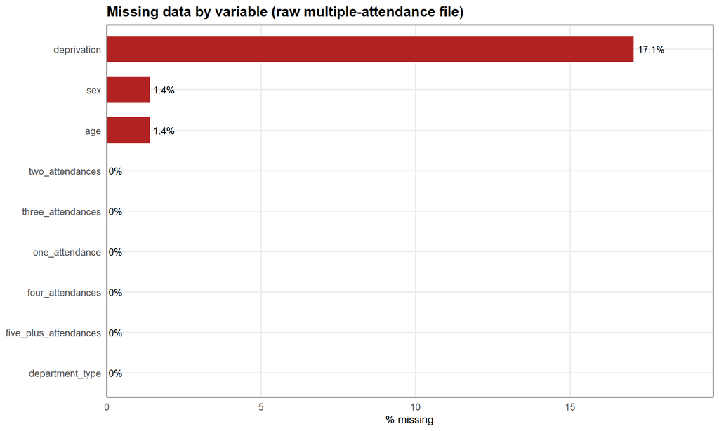

```r
# visualization of missingness
ggplot(missing_summary, aes(x = reorder(variable, pct_missing), y = pct_missing)) +
  geom_col(fill = "firebrick", width = 0.65) +
  geom_text(aes(label = paste0(round(pct_missing, 1), "%")), hjust = -0.15, size = 3.4) +
  coord_flip(clip = "off") +
  scale_y_continuous(expand = expansion(mult = c(0, 0.15))) +
  labs(title = "Missing data by variable (raw multiple-attendance file)",
       x = NULL, y = "% missing") +
  eda_theme
```

```r
save_fig("fig1_missing_data.png", width = 7.5, height = 4.5)
```

We proceed under a stated MAR simplification and analyse complete cases (Section 2.2.2 of the report). Imputation was not attempted, since assigning a deprivation value to people without a fixed address would fabricate a profile for them.

```r
# complete-case exclusion, derive frequent/total and merge both
# disease prevalence and population
freq_data_prefilter <- multiple_attendance %>%
  filter(!is.na(age), !is.na(sex), !is.na(deprivation)) %>% #delete NA
  mutate(
    age = factor(age, levels = c("Under 18", "18-24", "25-39",
                                  "40-64", "65-74", "75 plus")),
    sex = factor(sex),
    sex_pop = ifelse(sex == "Female", "Females", "Males"), #standardising label before merging
    deprivation = factor(deprivation, levels = 1:5,
                          labels = c("1 (most deprived)", "2", "3", "4",
                                     "5 (least deprived)")),
    department_type = factor(department_type),
    total_individuals = one_attendance + two_attendances + three_attendances +
                         four_attendances + five_plus_attendances,
    frequent = three_attendances + four_attendances + five_plus_attendances, #deriving frequent
    prop_frequent = frequent/total_individuals
  ) %>%
  filter(total_individuals > 0) %>%
  left_join(hbt_disease_prevalence %>% filter(year == 2025), by = "hbt") %>%
  left_join(hbt_age_sex_population %>% filter(year == 2025) %>% rename(sex_pop = sex),
            by = c("hbt", "age", "sex_pop"))

# check, not silently drop, rows losing their population match at the join
n_dropped_join <- sum(is.na(freq_data_prefilter$population))
cat("Rows dropped due to unmatched population join:", n_dropped_join, "\n")
```

```
## Rows dropped due to unmatched population join: 0
```

```r
freq_data <- freq_data_prefilter %>% filter(!is.na(population), population > 0)
cat("Final analysis strata (n):", nrow(freq_data), "\n")
```

```
## Final analysis strata (n): 1307
```

## 2.3 Exploratory Data Analysis (2.3)

### 2.3.1 Distribution of Frequent Attendance (2.3.1)

The mean/variance comparison here is the direct justification for negative binomial over Poisson, used formally again in Section 3.1.

```r
#checking dispersion
dispersion_summary <- freq_data %>%
  summarise(n = n(), mean = mean(frequent), variance = var(frequent),
            sd = sd(frequent), var_mean_ratio = variance / mean)
print(dispersion_summary)
```

```
##      n     mean variance       sd var_mean_ratio
## 1 1307 66.06963 17024.93 130.4796       257.6817
```

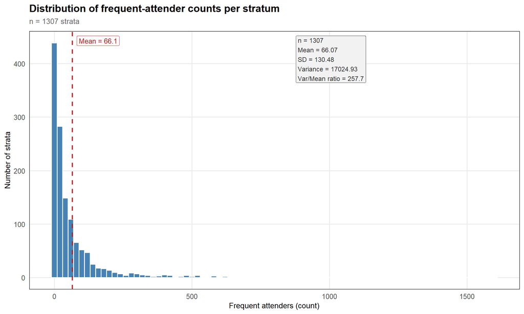

```r
# visualise with histogram
ggplot(freq_data, aes(x = frequent)) +
  geom_histogram(binwidth = 20, fill = "steelblue", colour = "white") +
  geom_vline(xintercept = dispersion_summary$mean, colour = "firebrick",
             linetype = "dashed", linewidth = 0.8) +
  annotate("label", x = dispersion_summary$mean, y = Inf,
           label = paste0("Mean = ", round(dispersion_summary$mean, 1)),
           colour = "firebrick", fill = "white", size = 3.4,
           vjust = 1.5, hjust = -0.1, label.size = 0.3) +
  annotate("label", x = max(freq_data$frequent, na.rm = TRUE) * 0.55, y = Inf,
           label = paste0(
             "n = ", dispersion_summary$n, "\n",
             "Mean = ", round(dispersion_summary$mean, 2), "\n",
             "SD = ", round(dispersion_summary$sd, 2), "\n",
             "Variance = ", round(dispersion_summary$variance, 2), "\n",
             "Var/Mean ratio = ", round(dispersion_summary$var_mean_ratio, 1)),
           hjust = 0, vjust = 1.1, size = 3.2, colour = "grey20",
           fill = "grey95", label.size = 0.3) +
  labs(title = "Distribution of frequent-attender counts per stratum",
       subtitle = paste0("n = ", dispersion_summary$n, " strata"),
       x = "Frequent attenders (count)", y = "Number of strata") +
  eda_theme
```

```r
save_fig("fig2_frequent_distribution.png", width = 8, height = 5.5)
```

### 2.3.2 Demographic and Deprivation Patterns (2.3.2)

One combined figure only, deprivation x age x sex together, since that is what the report interprets: whether the deprivation gradient holds within every age/sex panel.

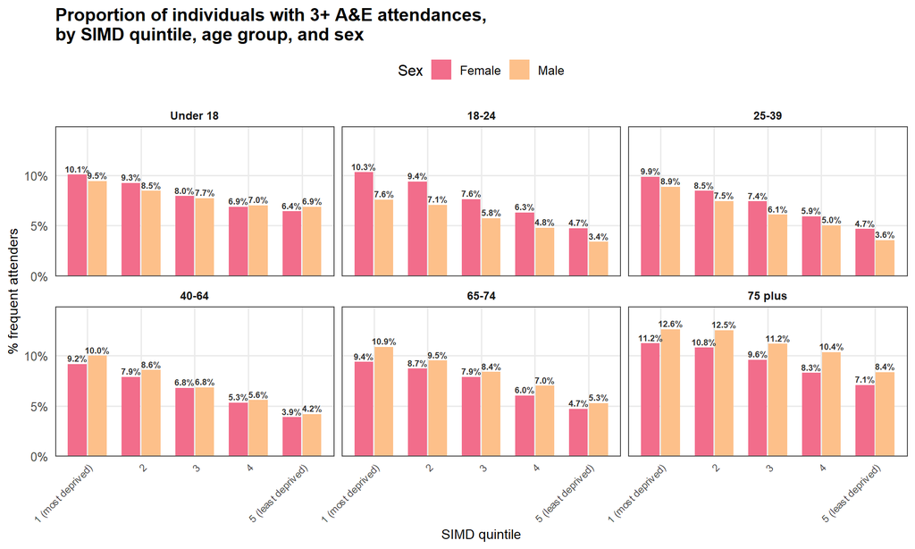

```r
by_deprivation_age_sex <- freq_data %>%
  group_by(deprivation, age, sex) %>%
  summarise(frequent = sum(frequent), total = sum(total_individuals), .groups = "drop") %>%
  mutate(prop_frequent = frequent / total)

#visualise the relationship between demographic, deprivation, and frequent
ggplot(by_deprivation_age_sex, aes(x = deprivation, y = prop_frequent, fill = sex)) +
  geom_col(position = position_dodge(width = 0.75), width = 0.7) +
  geom_text(aes(label = scales::percent(prop_frequent, accuracy = 0.1)),
            position = position_dodge(width = 0.75),
            vjust = -0.4, size = 2.4, fontface = "bold", colour = "grey20") +
  scale_y_continuous(labels = scales::percent, expand = expansion(mult = c(0, 0.18))) +
  scale_fill_manual(values = c("Female" = "#F26D8B", "Male" = "#FDC08A")) +
  facet_wrap(~ age, nrow = 2) +
  labs(title = "Proportion of individuals with 3+ A&E attendances,\nby SIMD quintile, age group, and sex",
       x = "SIMD quintile", y = "% frequent attenders", fill = "Sex") +
  eda_theme +
  theme(axis.text.x = element_text(angle = 45, hjust = 1, size = 8),
        strip.text = element_text(face = "bold", size = 9),
        legend.position = "top")
```

```r
save_fig("fig3_deprivation_age_sex.png", width = 10, height = 7)
```

### 2.3.3 Disease Prevalence and Frequent Attendance (2.3.3)

One correlation matrix does two jobs: shows the outcome association, and flags collinearity among the ten candidates (|r| > 0.7 is treated as a concern, Dormann et al. 2013).

```r
board_level_summary <- freq_data %>%
  group_by(hbt) %>%
  summarise(frequent = sum(frequent), total = sum(total_individuals), .groups = "drop") %>%
  mutate(prop_frequent = frequent / total) %>%
  left_join(hbt_disease_prevalence %>% filter(year == 2025), by = "hbt")

disease_cor_mat <- board_level_summary %>%
  dplyr::select(prop_frequent, starts_with("rate_")) %>%
  cor(use = "pairwise.complete.obs")

print(round(disease_cor_mat, 2))
```

```
##                   prop_frequent rate_copd rate_chd rate_heartfailure
## prop_frequent              1.00     -0.10     0.26              0.40
## rate_copd                 -0.10      1.00     0.57             -0.04
## rate_chd                   0.26      0.57     1.00              0.72
## rate_heartfailure          0.40     -0.04     0.72              1.00
## rate_diabetes             -0.04      0.75     0.81              0.32
## rate_ckd                   0.09     -0.01     0.49              0.78
## rate_epilepsy              0.04     -0.03     0.41              0.55
## rate_dementia              0.22      0.12     0.53              0.41
## rate_mentalhealth         -0.06      0.14     0.44              0.60
## rate_depression           -0.35      0.43     0.39              0.09
## rate_palliative            0.29     -0.37     0.00              0.13
##                   rate_diabetes rate_ckd rate_epilepsy rate_dementia
## prop_frequent             -0.04     0.09          0.04          0.22
## rate_copd                  0.75    -0.01         -0.03          0.12
## rate_chd                   0.81     0.49          0.41          0.53
## rate_heartfailure          0.32     0.78          0.55          0.41
## rate_diabetes              1.00     0.29          0.42          0.35
## rate_ckd                   0.29     1.00          0.53          0.19
## rate_epilepsy              0.42     0.53          1.00          0.31
## rate_dementia              0.35     0.19          0.31          1.00
## rate_mentalhealth          0.13     0.58          0.39          0.49
## rate_depression            0.50     0.26         -0.06          0.14
## rate_palliative           -0.10    -0.19          0.18          0.31
##                   rate_mentalhealth rate_depression rate_palliative
## prop_frequent                 -0.06           -0.35            0.29
## rate_copd                      0.14            0.43           -0.37
## rate_chd                       0.44            0.39            0.00
## rate_heartfailure              0.60            0.09            0.13
## rate_diabetes                  0.13            0.50           -0.10
## rate_ckd                       0.58            0.26           -0.19
## rate_epilepsy                  0.39           -0.06            0.18
## rate_dementia                  0.49            0.14            0.31
## rate_mentalhealth              1.00            0.04           -0.11
## rate_depression                0.04            1.00           -0.21
## rate_palliative               -0.11           -0.21            1.00
```

```r
# make heatmap to check correlation between continuous variables
png("Figures/fig4_disease_correlation.png", width = 950, height = 850, res = 150)
corrplot(disease_cor_mat, method = "color", type = "full",
         addCoef.col = "black", number.cex = 0.65,
         tl.col = "black", tl.srt = 45, tl.cex = 0.75,
         col = colorRampPalette(c("#4575B4", "white", "#D63C7E"))(200),
         title = "Pearson correlation: frequent attenders and\ncandidate disease-prevalence rates (Board level)",
         mar = c(0, 0, 3, 0))
dev.off()
```

```r
# collinearity check via VIF on a full model (all vars) with all ten rates
# narrows the candidate list before the final model is fitted
obj1b_kitchensink <- glmmTMB(
  frequent ~ age + sex + deprivation + department_type +
    rate_copd + rate_chd + rate_heartfailure + rate_diabetes + rate_ckd +
    rate_epilepsy + rate_dementia + rate_mentalhealth + rate_depression +
    rate_palliative + offset(log(population)) + (1 | hbt),
  family = nbinom2, data = freq_data
)
check_collinearity(obj1b_kitchensink)
```

| Term | VIF | VIF_CI_low | VIF_CI_high | SE_factor | Tolerance | Tolerance_CI_low | Tolerance_CI_high |
| --- | --- | --- | --- | --- | --- | --- | --- |
| age | 1.035233 | 1.007007 | 1.177156 | 1.003469 | 0.96596566 | 0.849505238 | 0.99304138 |
| sex | 1.004438 | 1.000000 | 787.042617 | 1.002216 | 0.99558180 | 0.001270579 | 0.99999997 |
| deprivation | 1.073291 | 1.031907 | 1.168350 | 1.008880 | 0.93171369 | 0.855907911 | 0.96907935 |
| department_type | 1.046900 | 1.013576 | 1.162025 | 1.023181 | 0.95520107 | 0.860566490 | 0.98660611 |
| rate_copd | 9.080749 | 8.218098 | 10.046497 | 3.013428 | 0.11012308 | 0.099537183 | 0.12168266 |
| rate_chd | 27.233212 | 24.539624 | 30.235022 | 5.218545 | 0.03671987 | 0.033074228 | 0.04075042 |
| rate_heartfailure | 19.658761 | 17.729139 | 21.810954 | 4.433820 | 0.05086791 | 0.045848522 | 0.05640432 |
| rate_diabetes | 17.007501 | 15.345293 | 18.862311 | 4.124015 | 0.05879759 | 0.053015773 | 0.06516656 |
| rate_ckd | 5.579128 | 5.069765 | 6.152242 | 2.362018 | 0.17923947 | 0.162542358 | 0.19724780 |
| rate_epilepsy | 3.760564 | 3.434799 | 4.129915 | 1.939217 | 0.26591758 | 0.242135763 | 0.29113786 |

[output cut: 4 more lines]

### 2.3.4 Population Adjustment (2.3.4)

Rates, not raw counts, are what matter here. we can see how varied the distribution of population

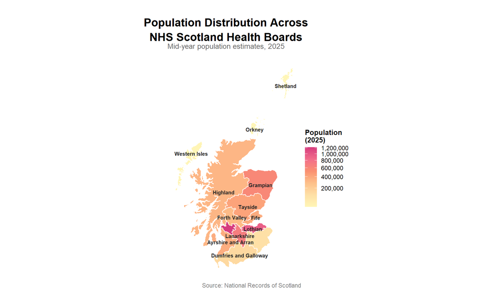

```r
hbt_total_population <- hbt_age_sex_population %>%
  filter(year == 2025) %>%
  group_by(hbt) %>%
  summarise(total_population = sum(population), .groups = "drop")

hb_pop_map <- hb_boundaries %>%
  left_join(hbt_total_population, by = c("HBCode" = "hbt"))

# Make cloropeth that shows population distribution
ggplot(hb_pop_map) +
  geom_sf(aes(fill = total_population), colour = "white", linewidth = 0.4) +
  geom_sf_text(aes(label = HBName), size = 2.6, colour = "grey15",
               fontface = "bold", check_overlap = TRUE) +
  scale_fill_gradientn(
    colours = c("#FFF6B7", "#FEE0A6", "#FDC08A", "#FA9070", "#F26D8B", "#D63C7E"),
    trans = "sqrt", labels = scales::comma,
    breaks = scales::pretty_breaks(n = 5), name = "Population\n(2025)"
  ) +
  labs(title = "Population Distribution Across\nNHS Scotland Health Boards",
       subtitle = "Mid-year population estimates, 2025",
       caption = "Source: National Records of Scotland") +
  theme_void(base_size = 12) +
  theme(
    plot.title = element_text(face = "bold", size = 16, hjust = 0.5, lineheight = 1.1),
    plot.subtitle = element_text(size = 10.5, colour = "grey40", hjust = 0.5, margin = margin(b = 10)),
    plot.caption = element_text(size = 8.5, colour = "grey50", hjust = 1),
    legend.title = element_text(face = "bold", size = 10),
    legend.text = element_text(size = 9),
    plot.margin = margin(20, 20, 15, 20)
  )
```

```r
save_fig("fig5_population_map.png", width = 9, height = 8)
```

# 3 Method

## 3.1 Model Construction (3.1)

```r
# Primary model
obj1b_model <- glmmTMB(
  frequent ~ age + sex + deprivation + department_type +
    rate_heartfailure + rate_depression +
    offset(log(population)) + (1 | hbt),
  family = nbinom2, data = freq_data
)
summary(obj1b_model)
```

```
##  Family: nbinom2  ( log )
## Formula:
## frequent ~ age + sex + deprivation + department_type + rate_heartfailure +
##     rate_depression + offset(log(population)) + (1 | hbt)
## Data: freq_data
##
##       AIC       BIC    logLik -2*log(L)  df.resid
##   11123.9   11206.7   -5545.9   11091.9      1291
##
## Random effects:
##
## Conditional model:
##  Groups Name        Variance Std.Dev.
##  hbt    (Intercept) 0.09571  0.3094
## Number of obs: 1307, groups:  hbt, 14
##
## Dispersion parameter for nbinom2 family (): 1.98
##
## Conditional model:
##                               Estimate Std. Error z value Pr(>|z|)
## (Intercept)                   -3.93307    1.03698   -3.79 0.000149 ***
## age18-24                      -0.08812    0.07536   -1.17 0.242296
## age25-39                      -0.23509    0.07360   -3.19 0.001402 **
## age40-64                      -0.41545    0.07242   -5.74 9.64e-09 ***
## age65-74                      -0.16062    0.07392   -2.17 0.029799 *
## age75 plus                     0.55332    0.07309    7.57 3.71e-14 ***
## sexMale                        0.03089    0.04249    0.73 0.467216
## deprivation2                   0.06772    0.06736    1.01 0.314719
## deprivation3                   0.20102    0.07084    2.84 0.004544 **
## deprivation4                  -0.15997    0.07049   -2.27 0.023250 *
## deprivation5 (least deprived) -0.76481    0.06969  -10.97  < 2e-16 ***
## department_typeType 3         -2.17156    0.05221  -41.59  < 2e-16 ***
## rate_heartfailure              0.64770    0.27452    2.36 0.018304 *
## rate_depression               -0.15660    0.06621   -2.37 0.018019 *
## ---
## Signif. codes:  0 '***' 0.001 '**' 0.01 '*' 0.05 '.' 0.1 ' ' 1
```

The random intercept is justified via an LRT against a variance-boundary null (no `hbt` term). The fixed-effect set must match exactly, or `df_diff != 1`.

```r
# Checking random effect
obj1b_null <- glmmTMB(
  frequent ~ age + sex + deprivation + department_type +
    rate_heartfailure + rate_depression +
    offset(log(population)),
  family = nbinom2, data = freq_data
)

lr_stat_b <- as.numeric(2 * (logLik(obj1b_model) - logLik(obj1b_null)))
df_diff_b <- attr(logLik(obj1b_model), "df") - attr(logLik(obj1b_null), "df")
lr_p_b <- pchisq(lr_stat_b, df = df_diff_b, lower.tail = FALSE) / 2
lr_stat_b; df_diff_b; lr_p_b
```

```
## [1] 150.2986
```

```
## [1] 1
```

```
## [1] 7.458666e-35
```

```r
icc(obj1b_model)
```

| ICC_adjusted | ICC_unadjusted | optional |
| --- | --- | --- |
| 0.01617712 | 0.01306067 | FALSE |

## 3.2 Model Selection (3.2)

We tested all models to check which one is the best-fitted model (lower AIC)

```r
# M0: offset and (1|hbt) only
m0 <- glmmTMB(frequent ~ offset(log(population)) + (1 | hbt),
              family = nbinom2, data = freq_data)

# M1: + age, sex
m1 <- glmmTMB(frequent ~ age + sex + offset(log(population)) + (1 | hbt),
              family = nbinom2, data = freq_data)

# M2: + deprivation
m2 <- glmmTMB(frequent ~ age + sex + deprivation + offset(log(population)) + (1 | hbt),
              family = nbinom2, data = freq_data)

# M3: + department type
m3 <- glmmTMB(frequent ~ age + sex + deprivation + department_type +
                offset(log(population)) + (1 | hbt),
              family = nbinom2, data = freq_data)

# M4: + heart failure, depression rate (= obj1b_model, the final specification)
m4 <- obj1b_model

# each row tested against the row above via LRT (block-wise, not term-by-term)
lrt_block <- function(m_small, m_big) {
  lr <- as.numeric(2 * (logLik(m_big) - logLik(m_small)))
  df <- attr(logLik(m_big), "df") - attr(logLik(m_small), "df")
  p  <- pchisq(lr, df = df, lower.tail = FALSE)
  tibble(chisq = lr, df = df, p_value = p)
}

model_selection_table <- bind_rows(
  tibble(model = "M0", predictors = "Offset and (1|hbt) only",
         df = attr(logLik(m0), "df"), AIC = AIC(m0), chisq = NA, chisq_df = NA, p_value = NA),
  bind_cols(model = "M1", predictors = "M0 + age, sex",
            df = attr(logLik(m1), "df"), AIC = AIC(m1), lrt_block(m0, m1) %>% rename(chisq_df = df)),
  bind_cols(model = "M2", predictors = "M1 + deprivation",
            df = attr(logLik(m2), "df"), AIC = AIC(m2), lrt_block(m1, m2) %>% rename(chisq_df = df)),
  bind_cols(model = "M3", predictors = "M2 + department type",
            df = attr(logLik(m3), "df"), AIC = AIC(m3), lrt_block(m2, m3) %>% rename(chisq_df = df)),
  bind_cols(model = "M4", predictors = "M3 + heart failure, depression rate",
            df = attr(logLik(m4), "df"), AIC = AIC(m4), lrt_block(m3, m4) %>% rename(chisq_df = df))
)

model_selection_table %>%
  knitr::kable(digits = 2, caption = "Model comparison for selecting final predictors (Table 1).")
```

Model comparison for selecting final predictors (Table 1).

| model | predictors | df | AIC | chisq | chisq_df | p_value |
| --- | --- | --- | --- | --- | --- | --- |
| M0 | Offset and (1\|hbt) only | 3 | 12301.04 | NA | NA | NA |
| M1 | M0 + age, sex | 9 | 12230.81 | 82.23 | 6 | 0.00 |
| M2 | M1 + deprivation | 13 | 12134.40 | 104.41 | 4 | 0.00 |
| M3 | M2 + department type | 14 | 11127.59 | 1008.81 | 1 | 0.00 |
| M4 | M3 + heart failure, depression rate | 16 | 11123.89 | 7.70 | 2 | 0.02 |

M4 is taken forward as the final specification

## 3.3 Sensitivity Analysis for Final Model (3.3)

### 3.3.1 Model Assumption and Diagnostic (Appendix A.1)

Simulation-based residual diagnostics from `DHARMa`, run on M4, avoid applying linear-model residual checks directly to count data.

```r
obj1b_sim <- simulateResiduals(obj1b_model, n = 1000)

# base-R plots all follow the same png()/plot/dev.off() shape, differing
# only in filename, dimensions, and which plotting call runs
save_base_plot <- function(filename, expr, width, height, res = 300) {
  png(file.path("Figures", filename), width = width, height = height, units = "in", res = res)
  eval.parent(substitute(expr))
  dev.off()
}

save_base_plot("diag_dharma_overall.png",  plot(obj1b_sim),                        width = 10, height = 5)
```

```r
save_base_plot("diag_residuals.png",       plotResiduals(obj1b_sim),               width = 8,  height = 5)
```

```r
save_base_plot("diag_outliers.png",        testOutliers(obj1b_sim, type = "bootstrap"), width = 6, height = 5)  # bootstrapped, preferred at this sample size
```

```r
save_base_plot("diag_dispersion.png",      testDispersion(obj1b_sim),              width = 6,  height = 5)
```

```r
save_base_plot("diag_zeroinflation.png",   testZeroInflation(obj1b_sim),           width = 6,  height = 5)  # this is the one that flags a genuine gap
```

KS test and dispersion test both pass. the zero-inflation test does not (M4 under-predicts zero-count strata). This motivates the ZINB check below, reported as a limitation, not a change to the primary model.

### 3.3.2 Poisson vs NB vs ZINB comparison (Figures 6-7)

```r
pois_fit <- glmmTMB(frequent ~ age + sex + deprivation + department_type +
                      rate_heartfailure + rate_depression +
                      offset(log(population)) + (1 | hbt),
                    family = poisson, data = freq_data)

obj1b_zinb_dept <- glmmTMB(
  frequent ~ age + sex + deprivation + department_type +
    rate_heartfailure + rate_depression +
    offset(log(population)) + (1 | hbt),
  ziformula = ~ department_type,
  family = nbinom2, data = freq_data
)
```

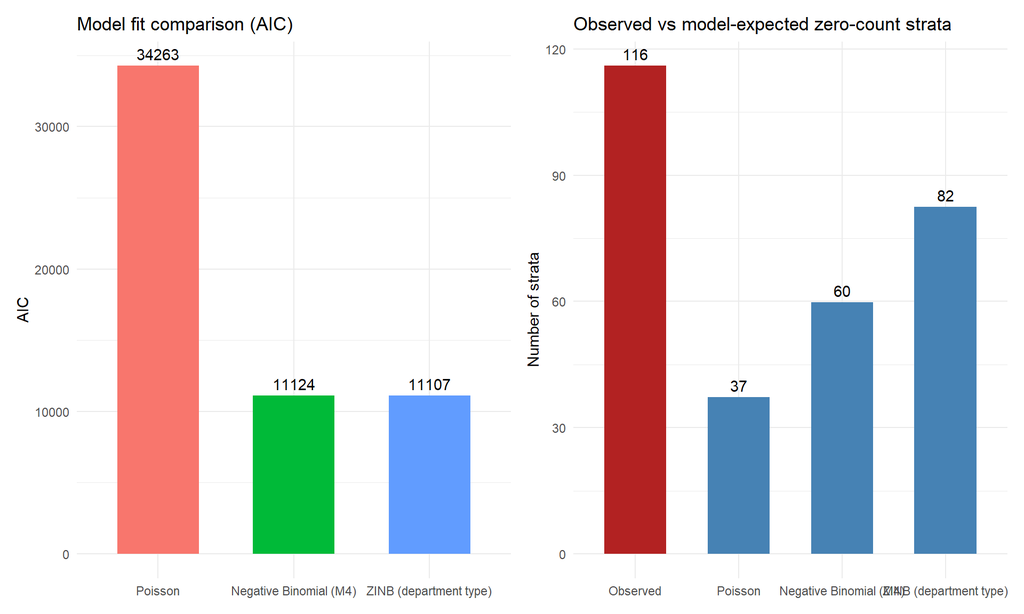

```r
# Panel 1, AIC comparison
aic_df <- data.frame(
  model = c("Poisson", "Negative Binomial (M4)", "ZINB (department type)"),
  AIC = c(AIC(pois_fit), AIC(obj1b_model), AIC(obj1b_zinb_dept))
)
aic_df$model <- factor(aic_df$model, levels = aic_df$model)

p1 <- ggplot(aic_df, aes(x = model, y = AIC, fill = model)) +
  geom_col(width = 0.6, show.legend = FALSE) +
  geom_text(aes(label = round(AIC, 0)), vjust = -0.5) +
  labs(title = "Model fit comparison (AIC)", x = NULL, y = "AIC") +
  theme_minimal()

# Panel 2, observed vs model-expected zero-count strata
obs_zeros <- sum(freq_data$frequent == 0)

sim_pois <- simulateResiduals(pois_fit, n = 1000)
sim_nb   <- simulateResiduals(obj1b_model, n = 1000)
sim_zinb <- simulateResiduals(obj1b_zinb_dept, n = 1000)

exp_zeros <- function(sim) mean(colSums(sim$simulatedResponse == 0))

zero_df <- data.frame(
  model = c("Observed", "Poisson", "Negative Binomial (M4)", "ZINB (department type)"),
  zeros = c(obs_zeros, exp_zeros(sim_pois), exp_zeros(sim_nb), exp_zeros(sim_zinb))
)
zero_df$model <- factor(zero_df$model, levels = zero_df$model)

# Plot for sensitivity check regarding zero-inflation
p2 <- ggplot(zero_df, aes(x = model, y = zeros, fill = model == "Observed")) +
  geom_col(width = 0.6, show.legend = FALSE) +
  geom_text(aes(label = round(zeros, 0)), vjust = -0.5) +
  scale_fill_manual(values = c("TRUE" = "firebrick", "FALSE" = "steelblue")) +
  labs(title = "Observed vs model-expected zero-count strata", x = NULL, y = "Number of strata") +
  theme_minimal()

p1 + p2   # Figure 6
```

```r
save_fig("fig6_sensitivity_comparison.png", plot = p1 + p2, width = 10, height = 5)
```

Sensitivity check of coefficients from all proposed distribution

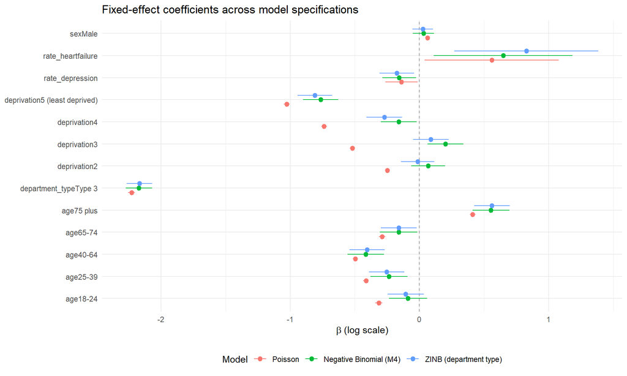

```r
# export the coefficient from all models
extract_coefs <- function(model, label) {
  tidy(model, effects = "fixed", conf.int = TRUE) %>%
    filter(component == "cond", term != "(Intercept)") %>%
    mutate(model = label)
}

coef_df <- bind_rows(
  extract_coefs(pois_fit,        "Poisson"),
  extract_coefs(obj1b_model,     "Negative Binomial (M4)"),
  extract_coefs(obj1b_zinb_dept, "ZINB (department type)")
)
coef_df$model <- factor(coef_df$model,
                        levels = c("Poisson", "Negative Binomial (M4)", "ZINB (department type)"))

#plotting
ggplot(coef_df, aes(x = estimate, y = term, colour = model)) +
  geom_vline(xintercept = 0, linetype = "dashed", colour = "grey60") +
  geom_pointrange(aes(xmin = conf.low, xmax = conf.high),
                  position = position_dodge(width = 0.6), size = 0.4) +
  labs(title = "Fixed-effect coefficients across model specifications",
       x = expression(beta~"(log scale)"), y = NULL, colour = "Model") +
  theme_minimal() +
  theme(legend.position = "bottom")
```

```r
save_fig("fig7_coef_comparison.png", width = 9, height = 7)
```

M4 and the ZINB extension agree on almost every predictor. heart failure prevalence is the only coefficient that shifts meaningfully (Section 3.3 of the report).

### 3.3.3 Zero-inflated Negative Binomial Model (Appendix A.2)

```r
# zero-inflation conditioned on department type only, the variable most
# plausibly associated with structural zeros (Type 3 sites)
zinb_ratio_dept <- exp_zeros(sim_zinb) / obs_zeros
cat("Observed/expected zero-count ratio, ZINB (department type):", round(zinb_ratio_dept, 2), "\n")
```

```
## Observed/expected zero-count ratio, ZINB (department type): 0.71
```

```r
# also tested: ~ deprivation + department_type, kept here as a
# documented negative result
# adding deprivation reintroduced a separation problem (huge SEs on
# deprivation2/4 in the zi component), not carried forward, kept only
# as evidence for why the department-type-only extension was preferred
obj1b_zinb_dep_dept <- glmmTMB(
  frequent ~ age + sex + deprivation + department_type +
    rate_heartfailure + rate_depression +
    offset(log(population)) + (1 | hbt),
  ziformula = ~ deprivation + department_type,
  family = nbinom2, data = freq_data
)
summary(obj1b_zinb_dep_dept)   # inspect the inflated SEs on deprivation terms
```

```
##  Family: nbinom2  ( log )
## Formula:
## frequent ~ age + sex + deprivation + department_type + rate_heartfailure +
##     rate_depression + offset(log(population)) + (1 | hbt)
## Zero inflation:            ~deprivation + department_type
## Data: freq_data
##
##       AIC       BIC    logLik -2*log(L)  df.resid
##   11055.7   11169.5   -5505.8   11011.7      1285
##
## Random effects:
##
## Conditional model:
##  Groups Name        Variance Std.Dev.
##  hbt    (Intercept) 0.1031   0.321
## Number of obs: 1307, groups:  hbt, 14
##
## Dispersion parameter for nbinom2 family (): 2.39
##
## Conditional model:
##                               Estimate Std. Error z value Pr(>|z|)
## (Intercept)                   -3.72326    1.06901   -3.48 0.000496 ***
## age18-24                      -0.10753    0.07045   -1.53 0.126909
## age25-39                      -0.25728    0.06865   -3.75 0.000178 ***
## age40-64                      -0.40307    0.06800   -5.93 3.07e-09 ***
## age65-74                      -0.15558    0.06940   -2.24 0.024976 *
## age75 plus                     0.56329    0.06857    8.21  < 2e-16 ***
## sexMale                        0.02534    0.03981    0.64 0.524440
## deprivation2                  -0.06441    0.06403   -1.01 0.314437
## deprivation3                   0.02668    0.06760    0.39 0.693122
## deprivation4                  -0.32892    0.06712   -4.90 9.55e-07 ***
## deprivation5 (least deprived) -0.80183    0.06887  -11.64  < 2e-16 ***
## department_typeType 3         -2.16209    0.04947  -43.70  < 2e-16 ***
## rate_heartfailure              0.94018    0.28516    3.30 0.000977 ***
## rate_depression               -0.18142    0.06829   -2.66 0.007895 **
## ---
## Signif. codes:  0 '***' 0.001 '**' 0.01 '*' 0.05 '.' 0.1 ' ' 1
##
## Zero-inflation model:
##                                Estimate Std. Error z value Pr(>|z|)
## (Intercept)                     -2.0327     0.2587  -7.856 3.97e-15 ***
## deprivation2                   -17.0626  1690.3477  -0.010  0.99195
## deprivation3                    -3.6223     1.3461  -2.691  0.00713 **
## deprivation4                   -19.1306  2982.6920  -0.006  0.99488
## deprivation5 (least deprived)   -0.1554     0.3761  -0.413  0.67952
## department_typeType 3           -0.2333     0.4571  -0.510  0.60976
## ---
## Signif. codes:  0 '***' 0.001 '**' 0.01 '*' 0.05 '.' 0.1 ' ' 1
```

```r
#checking between zinb and neg binomial
AIC(obj1b_model, obj1b_zinb_dept)   # lower AIC = preferred, penalised for the extra zi parameter
```

|  | df | AIC |
| --- | --- | --- |
| obj1b_model | 16 | 11123.89 |
| obj1b_zinb_dept | 18 | 11106.76 |

The ratio of observed to expected zero-count strata falls from 1.94 (M4) to about 1.4 once department type enters the zero-inflation component (Section A.2 of the report), confirming department type explains most, not all, of the excess zeros. M4 is retained as the primary specification throughout.

# 4 Result and Discussion

## 4.1 Table 2: Fitted Coefficients and Rate Ratios

```r
table2_results <- tidy(obj1b_model, effects = "fixed", component = "cond",
                        exponentiate = FALSE, conf.int = TRUE) %>%
  filter(term != "(Intercept)") %>%
  mutate(rate_ratio = exp(estimate),
         ci_low = exp(conf.low), ci_high = exp(conf.high)) %>%
  dplyr::select(term, estimate, rate_ratio, ci_low, ci_high, p.value)

table2_results %>%
  knitr::kable(digits = 3, caption = "Table 2. Fitted coefficients and rate ratios from the final negative binomial GLMM.")
```

Table 2. Fitted coefficients and rate ratios from the final negative binomial GLMM.

| term | estimate | rate_ratio | ci_low | ci_high | p.value |
| --- | --- | --- | --- | --- | --- |
| age18-24 | -0.088 | 0.916 | 0.790 | 1.061 | 0.242 |
| age25-39 | -0.235 | 0.790 | 0.684 | 0.913 | 0.001 |
| age40-64 | -0.415 | 0.660 | 0.573 | 0.761 | 0.000 |
| age65-74 | -0.161 | 0.852 | 0.737 | 0.984 | 0.030 |
| age75 plus | 0.553 | 1.739 | 1.507 | 2.007 | 0.000 |
| sexMale | 0.031 | 1.031 | 0.949 | 1.121 | 0.467 |
| deprivation2 | 0.068 | 1.070 | 0.938 | 1.221 | 0.315 |
| deprivation3 | 0.201 | 1.223 | 1.064 | 1.405 | 0.005 |
| deprivation4 | -0.160 | 0.852 | 0.742 | 0.978 | 0.023 |
| deprivation5 (least deprived) | -0.765 | 0.465 | 0.406 | 0.534 | 0.000 |
| department_typeType 3 | -2.172 | 0.114 | 0.103 | 0.126 | 0.000 |
| rate_heartfailure | 0.648 | 1.911 | 1.116 | 3.273 | 0.018 |
| rate_depression | -0.157 | 0.855 | 0.751 | 0.974 | 0.018 |

Sections 4.1-4.4 of the report walk through these rate ratios block by block (age, sex, deprivation, department type, disease prevalence); no separate code is needed beyond the table above.

## 4.2 Health Board Random Effect (4.5)

### 4.2.1 Caterpillar plot (Figure 9)

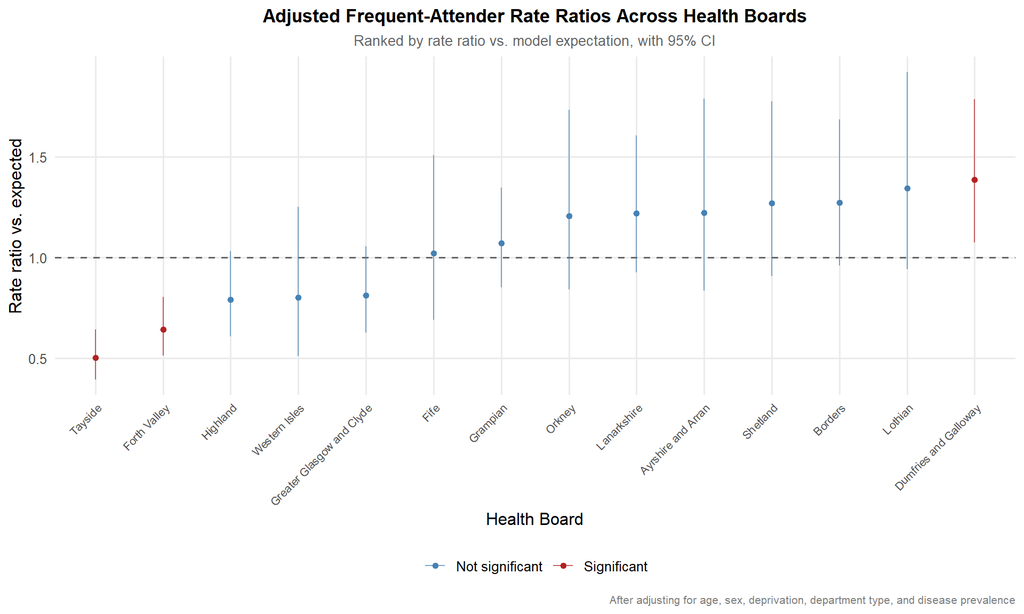

```r
# tidy() with ran_vals pulls the conditional variance needed for CIs,
# unlike ranef() alone
board_effects_ci <- tidy(obj1b_model, effects = "ran_vals", conf.int = TRUE) %>%
  filter(group == "hbt") %>%
  rename(hbt = level, log_effect = estimate) %>%
  mutate(
    rate_ratio = exp(log_effect),
    ci_low     = exp(conf.low),
    ci_high    = exp(conf.high),
    # significant if the 95% CI excludes 1 (genuinely differs from expected)
    significant = if_else(ci_low > 1 | ci_high < 1, "Significant", "Not significant")
  ) %>%
  arrange(rate_ratio) %>%
  mutate(hbt_rank = row_number())


hb_lookup <- hb_boundaries %>% st_drop_geometry() %>% dplyr::select(HBCode, HBName)

board_effects_ci <- board_effects_ci %>%
  left_join(hb_lookup, by = c("hbt" = "HBCode")) %>%
  mutate(hbt = factor(HBName, levels = HBName[order(rate_ratio)]))

ggplot(board_effects_ci, aes(x = hbt, y = rate_ratio, colour = significant)) +
  geom_hline(yintercept = 1, linetype = "dashed", colour = "grey40") +
  geom_errorbar(aes(ymin = ci_low, ymax = ci_high), width = 0, linewidth = 0.4, alpha = 0.7) +
  geom_point(size = 1.6) +
  scale_colour_manual(values = c("Significant" = "firebrick", "Not significant" = "steelblue")) +
  labs(
    title = "Adjusted Frequent-Attender Rate Ratios Across Health Boards",
    subtitle = "Ranked by rate ratio vs. model expectation, with 95% CI",
    x = "Health Board", y = "Rate ratio vs. expected", colour = NULL,
    caption = "After adjusting for age, sex, deprivation, department type, and disease prevalence"
  ) +
  theme_minimal(base_size = 12) +
  theme(
    plot.title = element_text(face = "bold", size = 13, hjust = 0.5),
    plot.subtitle = element_text(size = 10, colour = "grey40", hjust = 0.5),
    plot.caption = element_text(size = 8, colour = "grey50"),
    legend.position = "bottom",
    panel.grid.minor = element_blank(),
    axis.text.x = element_text(angle = 45, hjust = 1, size = 8)
  )
```

```r
save_fig("fig9_board_effects_caterpillar.png", width = 9, height = 6)
```

Only Tayside, Forth Valley, and Dumfries and Galloway have CIs that exclude 1. the remaining eleven boards sit within the range chance would produce.

### 4.2.2 Map (Figure 8)

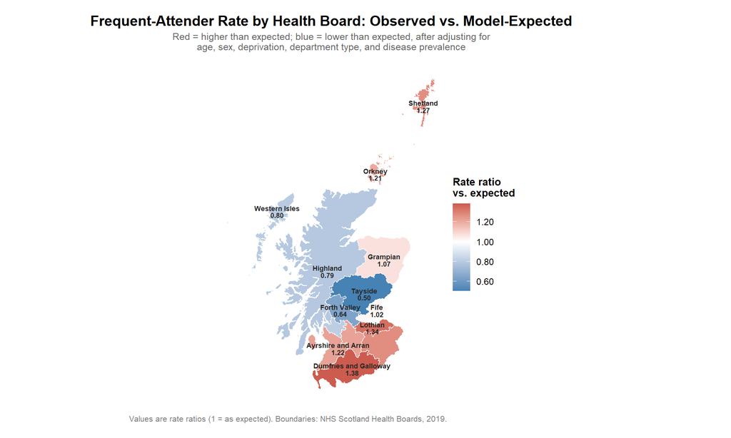

```r
board_effects <- ranef(obj1b_model)$cond$hbt %>%
  rownames_to_column("hbt") %>%
  rename(log_effect = `(Intercept)`) %>%
  mutate(rate_ratio_vs_expected = exp(log_effect),
         direction = if_else(log_effect > 0, "Higher than expected", "Lower than expected")) %>%
  arrange(desc(rate_ratio_vs_expected))


hb_map_data <- hb_boundaries %>%
  left_join(board_effects, by = c("HBCode" = "hbt")) %>%
  mutate(label_text = paste0(HBName, "\n", sprintf("%.2f", rate_ratio_vs_expected)))

ggplot(hb_map_data) +
  geom_sf(aes(fill = rate_ratio_vs_expected), colour = "white", linewidth = 0.3) +
  geom_sf_text(aes(label = label_text), size = 2.4, colour = "grey15",
               fontface = "bold", lineheight = 0.85, check_overlap = TRUE) +
  scale_fill_gradient2(
    low = "steelblue", mid = "white", high = "firebrick", midpoint = 1,
    labels = scales::number_format(accuracy = 0.01),
    name = "Rate ratio\nvs. expected"
  ) +
  labs(
    title = "Frequent-Attender Rate by Health Board: Observed vs. Model-Expected",
    subtitle = "Red = higher than expected; blue = lower than expected, after adjusting for\nage, sex, deprivation, department type, and disease prevalence",
    caption = "Values are rate ratios (1 = as expected). Boundaries: NHS Scotland Health Boards, 2019."
  ) +
  theme_void(base_size = 12) +
  theme(
    plot.title = element_text(face = "bold", size = 14, hjust = 0.5, margin = margin(b = 4)),
    plot.subtitle = element_text(size = 9.5, colour = "grey40", hjust = 0.5, margin = margin(b = 10)),
    plot.caption = element_text(size = 8, colour = "grey50", hjust = 1, margin = margin(t = 10)),
    legend.position = "right",
    legend.title = element_text(face = "bold", size = 10),
    legend.text = element_text(size = 9),
    plot.margin = margin(15, 15, 15, 15)
  )
```

```r
save_fig("fig8_board_effects_map.png", width = 9, height = 8)
```

# 5 Appendix A.3: Age-by-Sex Interaction Model

The main text reports the additive model. This tests `age * sex` in place of the additive terms, as a robustness check reported in Appendix A.3 and revisited in the Limitations section.

```r
obj1b_model_int <- glmmTMB(
  frequent ~ age * sex + deprivation + department_type +
    rate_heartfailure + rate_depression +
    offset(log(population)) + (1 | hbt),
  family = nbinom2, data = freq_data
)

anova(obj1b_model, obj1b_model_int)
```

|  | Df | AIC | BIC | logLik | deviance | Chisq | Chi Df | Pr(>Chisq) |
| --- | --- | --- | --- | --- | --- | --- | --- | --- |
| obj1b_model | 16 | 11123.89 | 11206.70 | -5545.945 | 11091.89 | NA | NA | NA |
| obj1b_model_int | 21 | 11119.36 | 11228.04 | -5538.678 | 11077.36 | 14.53421 | 5 | 0.01254952 |

```r
summary(obj1b_model_int)
```

```
##  Family: nbinom2  ( log )
## Formula:
## frequent ~ age * sex + deprivation + department_type + rate_heartfailure +
##     rate_depression + offset(log(population)) + (1 | hbt)
## Data: freq_data
##
##       AIC       BIC    logLik -2*log(L)  df.resid
##   11119.4   11228.0   -5538.7   11077.4      1286
##
## Random effects:
##
## Conditional model:
##  Groups Name        Variance Std.Dev.
##  hbt    (Intercept) 0.0954   0.3089
## Number of obs: 1307, groups:  hbt, 14
##
## Dispersion parameter for nbinom2 family (): 2.01
##
## Conditional model:
##                               Estimate Std. Error z value Pr(>|z|)
## (Intercept)                   -4.00040    1.03587   -3.86 0.000113 ***
## age18-24                       0.12390    0.10517    1.18 0.238751
## age25-39                      -0.12296    0.10319   -1.19 0.233395
## age40-64                      -0.34409    0.10182   -3.38 0.000727 ***
## age65-74                      -0.14940    0.10386   -1.44 0.150304
## age75 plus                     0.53413    0.10232    5.22 1.79e-07 ***
## sexMale                        0.15594    0.10239    1.52 0.127758
## deprivation2                   0.06772    0.06691    1.01 0.311511
## deprivation3                   0.20080    0.07038    2.85 0.004330 **
## deprivation4                  -0.16077    0.07002   -2.30 0.021679 *
## deprivation5 (least deprived) -0.76585    0.06926  -11.06  < 2e-16 ***
## department_typeType 3         -2.16740    0.05194  -41.73  < 2e-16 ***
## rate_heartfailure              0.64622    0.27398    2.36 0.018344 *
## rate_depression               -0.15639    0.06608   -2.37 0.017943 *
## age18-24:sexMale              -0.44355    0.14899   -2.98 0.002910 **
## age25-39:sexMale              -0.22158    0.14534   -1.52 0.127371
## age40-64:sexMale              -0.13830    0.14334   -0.96 0.334609
## age65-74:sexMale              -0.02029    0.14610   -0.14 0.889532
## age75 plus:sexMale             0.03836    0.14396    0.27 0.789871
## ---
## Signif. codes:  0 '***' 0.001 '**' 0.01 '*' 0.05 '.' 0.1 ' ' 1
```

```r
interaction_table <- tidy(obj1b_model_int, effects = "fixed", component = "cond",
                           conf.int = TRUE) %>%
  filter(term != "(Intercept)") %>%
  mutate(rate_ratio = exp(estimate), ci_low = exp(conf.low), ci_high = exp(conf.high))

interaction_table %>%
  knitr::kable(digits = 3, caption = "Table 3. Age-by-sex interaction model, conditional model coefficients.")
```

Table 3. Age-by-sex interaction model, conditional model coefficients.

| effect | component | term | estimate | std.error | statistic | p.value | conf.low | conf.high | rate_ratio | ci_low | ci_high |
| --- | --- | --- | --- | --- | --- | --- | --- | --- | --- | --- | --- |
| fixed | cond | age18-24 | 0.124 | 0.105 | 1.178 | 0.239 | -0.082 | 0.330 | 1.132 | 0.921 | 1.391 |
| fixed | cond | age25-39 | -0.123 | 0.103 | -1.192 | 0.233 | -0.325 | 0.079 | 0.884 | 0.722 | 1.083 |
| fixed | cond | age40-64 | -0.344 | 0.102 | -3.379 | 0.001 | -0.544 | -0.145 | 0.709 | 0.581 | 0.865 |
| fixed | cond | age65-74 | -0.149 | 0.104 | -1.438 | 0.150 | -0.353 | 0.054 | 0.861 | 0.703 | 1.056 |
| fixed | cond | age75 plus | 0.534 | 0.102 | 5.220 | 0.000 | 0.334 | 0.735 | 1.706 | 1.396 | 2.085 |
| fixed | cond | sexMale | 0.156 | 0.102 | 1.523 | 0.128 | -0.045 | 0.357 | 1.169 | 0.956 | 1.428 |
| fixed | cond | deprivation2 | 0.068 | 0.067 | 1.012 | 0.312 | -0.063 | 0.199 | 1.070 | 0.939 | 1.220 |
| fixed | cond | deprivation3 | 0.201 | 0.070 | 2.853 | 0.004 | 0.063 | 0.339 | 1.222 | 1.065 | 1.403 |
| fixed | cond | deprivation4 | -0.161 | 0.070 | -2.296 | 0.022 | -0.298 | -0.024 | 0.851 | 0.742 | 0.977 |
| fixed | cond | deprivation5 (least deprived) | -0.766 | 0.069 | -11.057 | 0.000 | -0.902 | -0.630 | 0.465 | 0.406 | 0.533 |
| fixed | cond | department_typeType 3 | -2.167 | 0.052 | -41.730 | 0.000 | -2.269 | -2.066 | 0.114 | 0.103 | 0.127 |
| fixed | cond | rate_heartfailure | 0.646 | 0.274 | 2.359 | 0.018 | 0.109 | 1.183 | 1.908 | 1.115 | 3.265 |
| fixed | cond | rate_depression | -0.156 | 0.066 | -2.367 | 0.018 | -0.286 | -0.027 | 0.855 | 0.751 | 0.973 |
| fixed | cond | age18-24:sexMale | -0.444 | 0.149 | -2.977 | 0.003 | -0.736 | -0.152 | 0.642 | 0.479 | 0.859 |
| fixed | cond | age25-39:sexMale | -0.222 | 0.145 | -1.525 | 0.127 | -0.506 | 0.063 | 0.801 | 0.603 | 1.065 |
| fixed | cond | age40-64:sexMale | -0.138 | 0.143 | -0.965 | 0.335 | -0.419 | 0.143 | 0.871 | 0.658 | 1.153 |
| fixed | cond | age65-74:sexMale | -0.020 | 0.146 | -0.139 | 0.890 | -0.307 | 0.266 | 0.980 | 0.736 | 1.305 |
| fixed | cond | age75 plus:sexMale | 0.038 | 0.144 | 0.266 | 0.790 | -0.244 | 0.321 | 1.039 | 0.784 | 1.378 |

Only the 18-24 x Male interaction is significant. the other four age bands show no departure from the additive pattern. The additive model (M4) is retained as the primary specification, and the young-men result is flagged for further work rather than folded into the general age effect (Section 6 of the report).